# R Notebook

```r
print(cars)
```

| speed | dist |
| --- | --- |
| 4 | 2 |
| 4 | 10 |
| 7 | 4 |
| 7 | 22 |
| 8 | 16 |
| 9 | 10 |
| 10 | 18 |
| 10 | 26 |
| 10 | 34 |
| 11 | 17 |

[output cut: 40 more lines]

```r
NA
```

```r
EmpNo <- c(1000, 1001, 1002, 1003, 1004)
EmpName <- c('Jack', 'Jane', 'Margaritta', 'Joe', 'Dave')
ProjName <- c('PO1', 'PO2', 'PO3', 'PO4', 'PO5')
Employee <- data.frame(EmpNo, EmpName, ProjName)
print(Employee)
```

| EmpNo | EmpName | ProjName |
| --- | --- | --- |
| 1000 | Jack | PO1 |
| 1001 | Jane | PO2 |
| 1002 | Margaritta | PO3 |
| 1003 | Joe | PO4 |
| 1004 | Dave | PO5 |

```r
print(Employee[1,1])
```

```
[1] 1000
```

```r
row.names(Employee)<-c("Emp1","Emp2","Emp3","Emp4","Emp5")
print(Employee)
```

|  | EmpNo | EmpName | ProjName |
| --- | --- | --- | --- |
| Emp1 | 1000 | Jack | PO1 |
| Emp2 | 1001 | Jane | PO2 |
| Emp3 | 1002 | Margaritta | PO3 |
| Emp4 | 1003 | Joe | PO4 |
| Emp5 | 1004 | Dave | PO5 |

```r
Employee["Emp1",]
```

|  | EmpNo | EmpName | ProjName |
| --- | --- | --- | --- |
| Emp1 | 1000 | Jack | PO1 |

```r
sno=c(1,2,3,5)
x=c(1,3,56, NA)
m1=c(3,4,5,6)
dataf=data.frame(sno,x,m1)
print(dataf)
```

| sno | x | m1 |
| --- | --- | --- |
| 1 | 1 | 3 |
| 2 | 3 | 4 |
| 3 | 56 | 5 |
| 5 | NA | 6 |

```r
NA | TRUE
```

```
[1] TRUE
```

```r
NA | FALSE
```

```
[1] NA
```

```r
NA & TRUE
```

```
[1] NA
```

```r
NA & FALSE
```

```
[1] FALSE
```

```r
is.na(x)
```

```
[1] FALSE FALSE FALSE  TRUE
```

```r
dataf[c(FALSE,TRUE,FALSE),]
```

|  | sno | x | m1 |
| --- | --- | --- | --- |
| 2 | 2 | 3 | 4 |

```r
dataf$x>2
```

```
[1] FALSE  TRUE  TRUE    NA
```

```r
dataf[dataf$x>2]
```

```
Error in `[.data.frame`(dataf, dataf$x > 2) : undefined columns selected
```

```r
Employee$EmpExpYears <-c(5, 9, 6, 12, 7)
print(Employee)
```

|  | EmpNo | EmpName | ProjName | EmpExpYears |
| --- | --- | --- | --- | --- |
| Emp1 | 1000 | Jack | PO1 | 5 |
| Emp2 | 1001 | Jane | PO2 | 9 |
| Emp3 | 1002 | Margaritta | PO3 | 6 |
| Emp4 | 1003 | Joe | PO4 | 12 |
| Emp5 | 1004 | Dave | PO5 | 7 |

```r
print(order(Employee$EmpExpYears))
```

```
[1] 1 3 5 2 4
```

```r
print(sort(Employee$EmpExpYears))
```

```
[1]  5  6  7  9 12
```

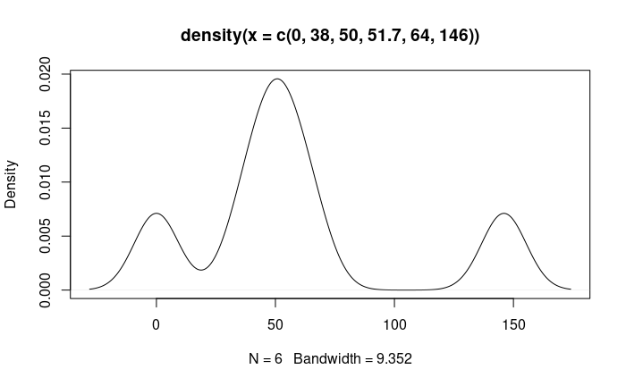

```r
# Create data for the density plot
h <- density (c(0.0, 38.0, 50.0, 51.7, 64.0, 146.0))
#Create density plot for h
plot(h)
```

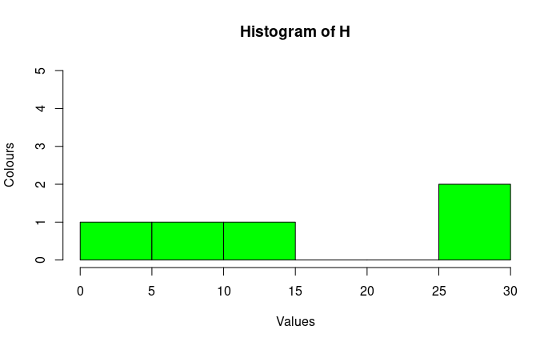

```r
H <- c (8, 13, 30, 5, 28)
bins <- c(0, 5, 10, 15, 20, 25, 30)
#bins
hist(H, xlab ='Values', ylab='Colours', col='green', xlim=c(0,30), ylim=c(0,5), breaks=bins)
```

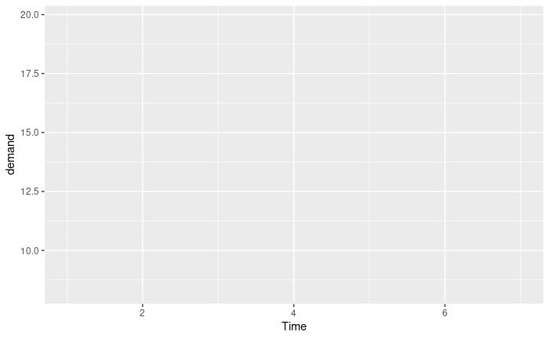

```r
library(ggplot2)
#data()
?BOD
ggplot(data=BOD, mapping=aes(x=Time, y=demand))
```

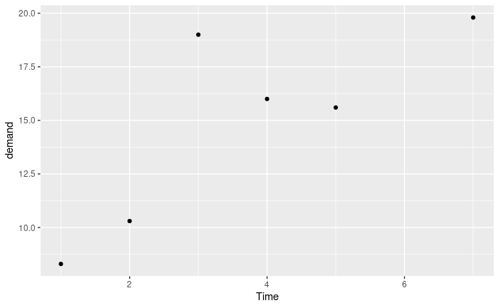

```r
ggplot(data=BOD, mapping=aes(x=Time, y=demand))+geom_point()
```

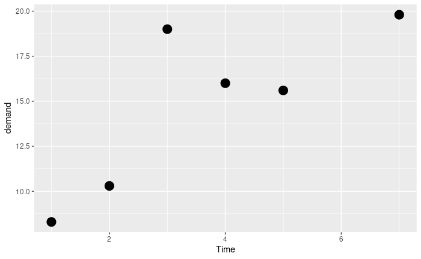

```r
ggplot(data=BOD, mapping=aes(x=Time, y=demand))+geom_point(size=5)
```

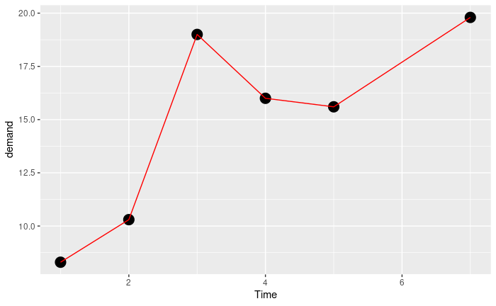

```r
ggplot(data=BOD, mapping=aes(x=Time, y=demand))+geom_point(size=5)+geom_line(color='red')
```

```r
#Define a vector
x<- c(15,54,6,5,9.2,36,5.3,8,-7,-5)
# Find the mean of the vector inputs
result.mean <- mean(x)
print(result.mean)
```

```
[1] 12.65
```

```r
#Define a vector
x<- c(15,54,6,5,9.2,36,5.3,8,-7,-5,NA)
# Find the mean of the vector inputs
result.mean <- mean(x)
print(result.mean)
```

```
[1] NA
```

```r
#Dropping NA values from finding the mean
result.mean <- mean(x, na.rm=TRUE)
print(result.mean)
```

```
[1] 12.65
```

```r
#Define a vector
x<- c(15,54,6,5,9.2,36,5.3,8,-7,-5)
# Find the median value
median.result <-median(x)
print(median.result)
```

```
[1] 7
```

```r
deviation <- sd(x)
print(deviation)
```

```
[1] 18.70385
```

```r
# Create data for the bar chart
H <- c (8,13,30,5,28)
#Give a name for the bar chart
png(file = 'samplebarchart.png')
#Plot bar chart using barplot() function
barplot(H, horiz=TRUE)
#Save the file
dev.off()
```

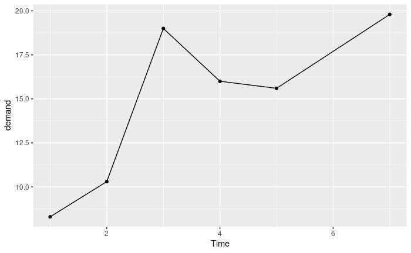

```r
ggplot(data=BOD, mapping=aes(Time,demand))+geom_point()+geom_line()
```

```r
CO2
```

```
Grouped Data: uptake ~ conc | Plant
   Plant        Type  Treatment conc uptake
1    Qn1      Quebec nonchilled   95   16.0
2    Qn1      Quebec nonchilled  175   30.4
3    Qn1      Quebec nonchilled  250   34.8
4    Qn1      Quebec nonchilled  350   37.2
5    Qn1      Quebec nonchilled  500   35.3
6    Qn1      Quebec nonchilled  675   39.2
7    Qn1      Quebec nonchilled 1000   39.7
8    Qn2      Quebec nonchilled   95   13.6
9    Qn2      Quebec nonchilled  175   27.3
10   Qn2      Quebec nonchilled  250   37.1
11   Qn2      Quebec nonchilled  350   41.8
12   Qn2      Quebec nonchilled  500   40.6
13   Qn2      Quebec nonchilled  675   41.4
```

[output cut: 71 more lines]

```r
unique(CO2$Treatment)
```

```
[1] nonchilled chilled
Levels: nonchilled chilled
```

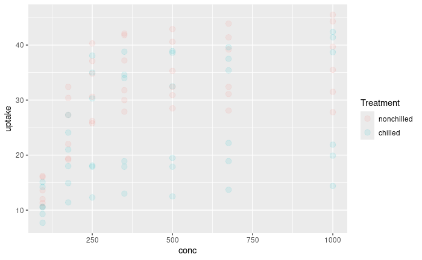

```r
ggplot(CO2, aes(conc,uptake,colour=Treatment))+geom_point(size=3,alpha=.1)
```

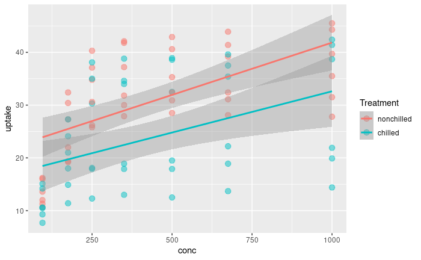

```r
ggplot(CO2, aes(conc,uptake,colour=Treatment))+geom_point(size=3,alpha=0.5)+ geom_smooth(method=lm)
```

```r
customer_data=read.csv("custdata.csv")

summary(customer_data)
```

```
    custid             gender          is_employed         income
 Length:73262       Length:73262       Mode :logical   Min.   :  -6900
 Class :character   Class :character   FALSE:2351      1st Qu.:  10700
 Mode  :character   Mode  :character   TRUE :45137     Median :  26200
                                       NA's :25774     Mean   :  41764
                                                       3rd Qu.:  51700
                                                       Max.   :1257000

 marital_status     health_ins      housing_type       recent_move
 Length:73262       Mode :logical   Length:73262       Mode :logical
 Class :character   FALSE:7307      Class :character   FALSE:62418
 Mode  :character   TRUE :65955     Mode  :character   TRUE :9123
                                                       NA's :1721



  num_vehicles        age         state_of_res         gas_usage
 Min.   :0.000   Min.   :  0.00   Length:73262       Min.   :  1.00
 1st Qu.:1.000   1st Qu.: 34.00   Class :character   1st Qu.:  3.00
 Median :2.000   Median : 48.00   Mode  :character   Median : 10.00
 Mean   :2.066   Mean   : 49.16                      Mean   : 41.17
 3rd Qu.:3.000   3rd Qu.: 62.00                      3rd Qu.: 60.00
 Max.   :6.000   Max.   :120.00                      Max.   :570.00
 NA's   :1720                                        NA's   :1720
```

```r
head(customer_data)
```

|  | custid | gender | is_employed | income | marital_status | health_ins | housing_type | recent_move | num_vehicles | age | state_of_res | gas_usage |
| --- | --- | --- | --- | --- | --- | --- | --- | --- | --- | --- | --- | --- |
| 1 | 000006646_03 | Male | TRUE | 22000 | Never married | TRUE | Homeowner free and clear | FALSE | 0 | 24 | Alabama | 210 |
| 2 | 000007827_01 | Female | NA | 23200 | Divorced/Separated | TRUE | Rented | TRUE | 0 | 82 | Alabama | 3 |
| 3 | 000008359_04 | Female | TRUE | 21000 | Never married | TRUE | Homeowner with mortgage/loan | FALSE | 2 | 31 | Alabama | 40 |
| 4 | 000008529_01 | Female | NA | 37770 | Widowed | TRUE | Homeowner free and clear | FALSE | 1 | 93 | Alabama | 120 |
| 5 | 000008744_02 | Male | TRUE | 39000 | Divorced/Separated | TRUE | Rented | FALSE | 2 | 67 | Alabama | 3 |
| 6 | 000011466_01 | Male | NA | 11100 | Married | TRUE | Homeowner free and clear | FALSE | 2 | 76 | Alabama | 200 |

```r
tail(customer_data)
```

|  | custid | gender | is_employed | income | marital_status | health_ins | housing_type | recent_move | num_vehicles | age | state_of_res | gas_usage |
| --- | --- | --- | --- | --- | --- | --- | --- | --- | --- | --- | --- | --- |
| 73257 | 001501555_01 | Female | TRUE | 85000 | Married | TRUE | Homeowner with mortgage/loan | FALSE | 2 | 32 | Wyoming | 70 |
| 73258 | 001506841_02 | Female | TRUE | 18500 | Never married | FALSE | Rented | FALSE | 1 | 25 | Wyoming | 10 |
| 73259 | 001507219_01 | Female | NA | 20800 | Widowed | TRUE | Homeowner free and clear | FALSE | 1 | 86 | Wyoming | 120 |
| 73260 | 001513103_01 | Male | TRUE | 75000 | Married | TRUE | Homeowner with mortgage/loan | FALSE | 2 | 50 | Wyoming | 90 |
| 73261 | 001519624_01 | Female | TRUE | 22200 | Divorced/Separated | FALSE | Homeowner free and clear | FALSE | 1 | 61 | Wyoming | 50 |
| 73262 | 001520877_01 | Male | TRUE | 16400 | Never married | TRUE | NA | NA | NA | 31 | Wyoming | NA |

The variable is_employed is missing for more than a third of the data. Why? Is employment status unknown? Did the company start collecting employment data only recently? Does NA mean “not in the active workforce” (for example, students or stay-at-home parents)?

```r
names(customer_data)
```

```
 [1] "custid"         "gender"         "is_employed"    "income"
 [5] "marital_status" "health_ins"     "housing_type"   "recent_move"
 [9] "num_vehicles"   "age"            "state_of_res"   "gas_usage"
```

```r
str(customer_data)
```

```
'data.frame':   73262 obs. of  12 variables:
 $ custid        : chr  "000006646_03" "000007827_01" "000008359_04" "000008529_01" ...
 $ gender        : chr  "Male" "Female" "Female" "Female" ...
 $ is_employed   : logi  TRUE NA TRUE NA TRUE NA ...
 $ income        : num  22000 23200 21000 37770 39000 ...
 $ marital_status: chr  "Never married" "Divorced/Separated" "Never married" "Widowed" ...
 $ health_ins    : logi  TRUE TRUE TRUE TRUE TRUE TRUE ...
 $ housing_type  : chr  "Homeowner free and clear" "Rented" "Homeowner with mortgage/loan" "Homeowner free and clear" ...
 $ recent_move   : logi  FALSE TRUE FALSE FALSE FALSE FALSE ...
 $ num_vehicles  : int  0 0 2 1 2 2 2 2 5 3 ...
 $ age           : int  24 82 31 93 67 76 26 73 27 54 ...
 $ state_of_res  : chr  "Alabama" "Alabama" "Alabama" "Alabama" ...
 $ gas_usage     : int  210 3 40 120 3 200 3 50 3 20 ...
```

```r
ncol(customer_data)
```

```
[1] 12
```

```r
nrow(customer_data)
```

```
[1] 73262
```

The variables housing_type, recent_move, num_vehicles, and gas_usage are missing relatively few values— about 2% of the data. It’s probably safe to just drop the rows that are missing values, especially if the missing values are all in the same 1720 rows.

```r
customer_data[order(customer_data$income),]
```

|  | custid | gender | is_employed | income | marital_status | health_ins | housing_type | recent_move | num_vehicles | age | state_of_res | gas_usage |
| --- | --- | --- | --- | --- | --- | --- | --- | --- | --- | --- | --- | --- |
| 3009 | 000616218_01 | Male | TRUE | -6900 | Married | TRUE | Rented | FALSE | 2 | 120 | Arkansas | 60 |
| 563 | 000841705_03 | Female | TRUE | -6800 | Married | TRUE | Homeowner free and clear | FALSE | 2 | 60 | Alabama | 3 |
| 38285 | 000343879_02 | Male | TRUE | -6800 | Married | TRUE | Rented | FALSE | 2 | 62 | Missouri | 3 |
| 42090 | 000790861_02 | Female | TRUE | -6700 | Married | TRUE | Homeowner with mortgage/loan | FALSE | 2 | 62 | New Jersey | 210 |
| 42843 | 001361033_01 | Male | TRUE | -6700 | Never married | TRUE | Homeowner with mortgage/loan | FALSE | 1 | 41 | New Jersey | 2 |
| 49858 | 001296313_01 | Male | TRUE | -6600 | Married | FALSE | Homeowner with mortgage/loan | FALSE | 5 | 57 | North Carolina | 3 |
| 40765 | 000465463_02 | Female | TRUE | -6100 | Married | TRUE | Homeowner with mortgage/loan | FALSE | 2 | 53 | New Hampshire | 570 |
| 15567 | 000205461_01 | Female | NA | -6000 | Married | TRUE | Rented | FALSE | 1 | 39 | Florida | 3 |
| 16573 | 000516588_01 | Female | TRUE | -6000 | Married | FALSE | Homeowner with mortgage/loan | FALSE | 2 | 60 | Florida | 30 |
| 16713 | 000561162_01 | Female | TRUE | -6000 | Married | TRUE | Homeowner with mortgage/loan | FALSE | 2 | 40 | Florida | 3 |

[output cut: 990 more lines]

INVALID VALUES AND OUTLIERS

```r
summary(customer_data$income)
```

```
   Min. 1st Qu.  Median    Mean 3rd Qu.    Max.
  -6900   10700   26200   41764   51700 1257000
```

Negative values for income could indicate bad data. They might also have a special meaning, like “amount of debt.” Either way, you should check how prevalent the issue is, and decide what to do. Do you drop the data with negative income? Do you convert negative values to zero?

```r
summary(customer_data$age)
```

```
   Min. 1st Qu.  Median    Mean 3rd Qu.    Max.
   0.00   34.00   48.00   49.16   62.00  120.00
```

Customers of age zero, or customers of an age greater than about 110, are outliers. They fall out of the range of expected customer values. Outliers could be data input errors. They could be special sentinel values: zero might mean “age unknown” or “refuse to state.” And some of your customers might be especially long-lived.

Outliers serve as captivating anomalies that frequently harbor profound insights within datasets. Despite appearing as erroneous data points, outliers possess the potential to offer valuable revelations about underlying processes or to reveal potential error in data collection.

```r
IncomeK = customer_data$income/1000
summary(IncomeK)
```

```
   Min. 1st Qu.  Median    Mean 3rd Qu.    Max.
  -6.90   10.70   26.20   41.76   51.70 1257.00
```

The variable IncomeK is defined as IncomeK = customer_data$income/1000. But suppose you didn’t know that. Looking only at the summary, the values could plausibly be interpreted to mean either “hourly wage” or “yearly income in units of $1000.” ————————————————————

```r
clean_customer_data=na.omit(customer_data)
nrow(clean_customer_data)
```

```
[1] 47208
```

```r
ncol(clean_customer_data)
```

```
[1] 12
```

```r
summary(clean_customer_data)
```

```
    custid             gender          is_employed         income
 Length:47208       Length:47208       Mode :logical   Min.   :  -6900
 Class :character   Class :character   FALSE:2321      1st Qu.:  20000
 Mode  :character   Mode  :character   TRUE :44887     Median :  37600
                                                       Mean   :  53713
                                                       3rd Qu.:  65000
                                                       Max.   :1257000
 marital_status     health_ins      housing_type       recent_move
 Length:47208       Mode :logical   Length:47208       Mode :logical
 Class :character   FALSE:4986      Class :character   FALSE:40302
 Mode  :character   TRUE :42222     Mode  :character   TRUE :6906



  num_vehicles        age         state_of_res         gas_usage
 Min.   :0.000   Min.   :  0.00   Length:47208       Min.   :  1.00
 1st Qu.:1.000   1st Qu.: 31.00   Class :character   1st Qu.:  3.00
 Median :2.000   Median : 43.00   Mode  :character   Median : 20.00
 Mean   :2.202   Mean   : 43.26                      Mean   : 41.28
 3rd Qu.:3.000   3rd Qu.: 54.00                      3rd Qu.: 60.00
 Max.   :6.000   Max.   :120.00                      Max.   :570.00
```

```r
dim(customer_data)
```

```
[1] 73262    12
```

```r
clean_recent_move=customer_data[!is.na(customer_data$recent_move),]
dim(clean_recent_move)
```

```
[1] 71541    12
```

1. A graphic should display as much information as it can, with the lowest possible cognitive strain to the viewer.
2. Strive for clarity. Make the data stand out. Specific tips for increasing clarity include these:
- Avoid too many superimposed elements, such as too many curves in the same graphing space.
- Find the right aspect ratio and scaling to properly bring out the details of the data.
- Avoid having the data all skewed to one side or the other of your graph.
6. Visualization is an iterative process. Its purpose is to answer questions about the data.

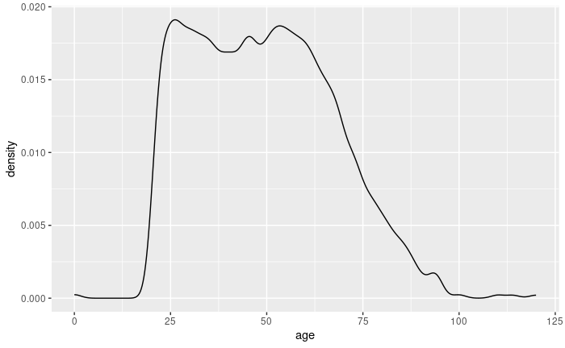

```r
library(ggplot2)
library(scales)
ggplot(data=customer_data,mapping = aes(x=age))+  geom_density()
```

Distribution peaks around mid/late 20s Peaks again in early 50s

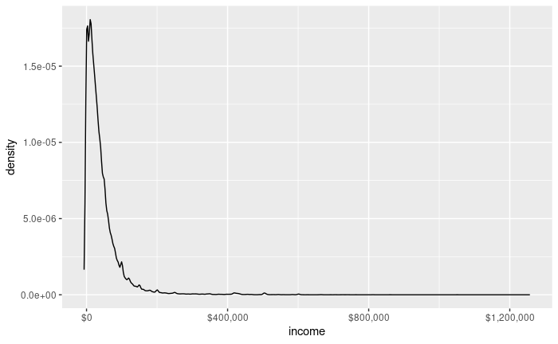

```r
ggplot(customer_data, aes(x=income)) + geom_density() + scale_x_continuous(labels=dollar)
```

Most of the distribution is concentrated at the low end: less than $200,000 a year. It’s hard to get good resolution here.

library(scales) The scales package brings in the dollar scale notation. Sets the x-axis labels to dollars Suspiciously high count of gas payments in the $0–10 range

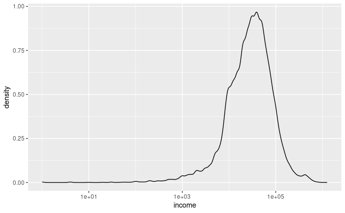

```r
ggplot(customer_data, aes(x=income)) +
geom_density() + scale_x_log10()
```

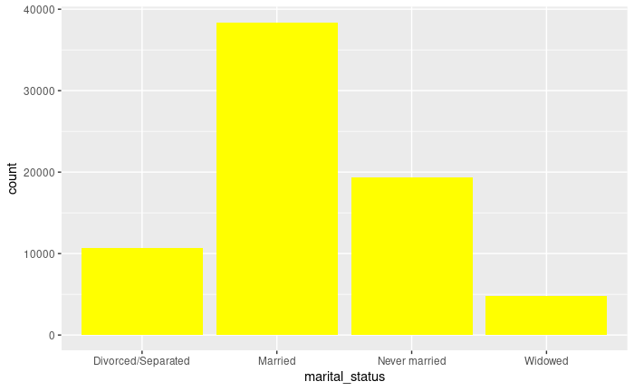

```r
ggplot(customer_data, aes(x=marital_status)) + geom_bar(fill="yellow")
```

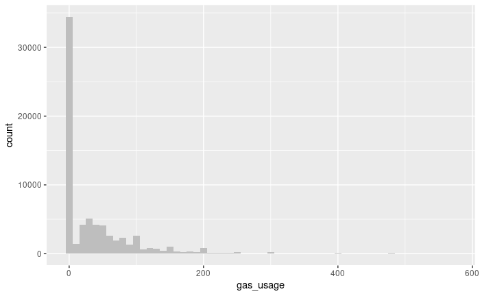

```r
ggplot(customer_data, aes(x=gas_usage)) + geom_histogram(binwidth=10, fill="gray")
```

Suspiciously high count of gas payments in the $0–10 range outliers at the end

```
Nominal: Categories with no order (e.g., gender, state).

Ordinal: Categories with order (e.g., education level — not present here).

Discrete: Countable numbers (e.g., num_vehicles).

Continuous: Measurable values on a scale, can take any value within a range (e.g., income, age).
```

| Attribute | Type | Explanation |
| --- | --- | --- |
| **custid** | *Nominal* | A unique identifier — treated as a label, no inherent order. |
| **gender** | *Nominal* | Categorical, no order between levels (e.g., Male, Female, Other). |
| **is_employed** | *Nominal* | Logical (TRUE/FALSE), can be treated as a nominal categorical variable. |
| **income** | *Continuous* | Numerical with many values; can take decimals. |
| **marital_status** | *Nominal* | Categorical with no inherent order (e.g., Married, Single). |
| **health_ins** | *Nominal* | Logical (TRUE/FALSE); again, considered nominal. |
| **housing_type** | *Nominal* | Categorical (e.g., Owned, Rented); no ordering. |
| **recent_move** | *Nominal* | Logical (TRUE/FALSE); treated as nominal. |
| **num_vehicles** | *Discrete* | Countable values (0, 1, 2…); can’t take fractions. |
| **age** | *Continuous* | Can be any numeric value; typically treated as continuous even if stored as integers. |
| **state_of_res** | *Nominal* | Geographic/categorical labels, unordered. |
| **gas_usage** | *Continuous* | Numerical, could be fractional (liters, kWh, etc.). |

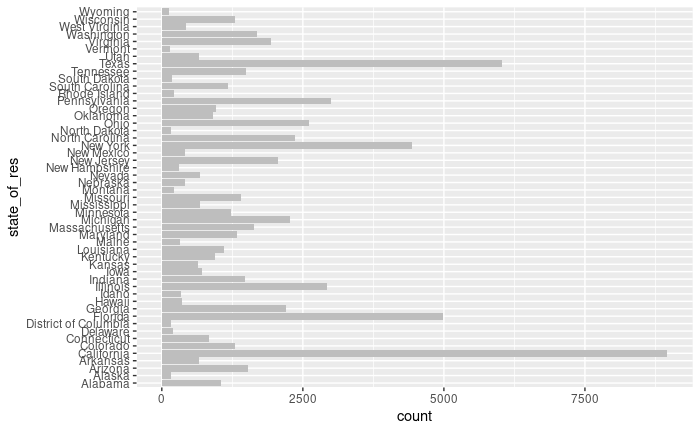

```r
ggplot(customer_data, aes(x=state_of_res))+geom_bar(fill="gray") +coord_flip()
```

Flips the x and y axes: state_of_res is now on the y-axis Plots bar chart as before: state_of_res is on x-axis, count is on y-axis

```r
head(customer_data$state_of_res)
```

```
[1] "Alabama" "Alabama" "Alabama" "Alabama" "Alabama" "Alabama"
```

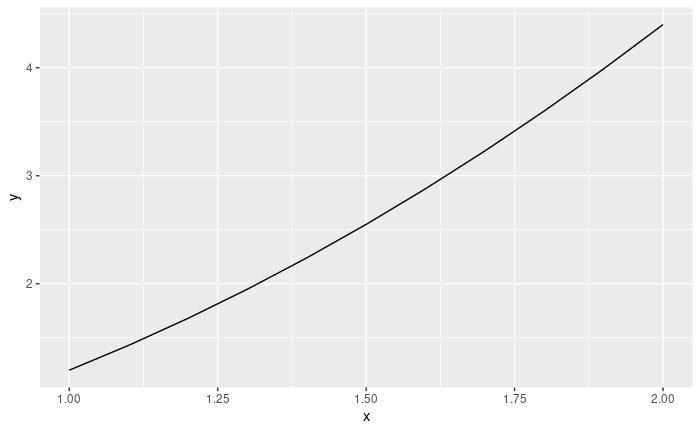

```r
x <- seq(1, 2, by = 0.1)
#quadratic function of x.
y <- x^2 + 0.2*x
ggplot(data.frame(x=x,y=y), aes(x=x,y=y)) + geom_line()
```

```r
customer_data2 <- subset(customer_data,
0 < age & age < 100 &
0 < income & income < 200000)

cor(customer_data2$age, customer_data2$income)
```

```
[1] 0.005766697
```

The correlation is positive, as you might expect, but nearly zero, meaning there is apparently not much relation between age and income

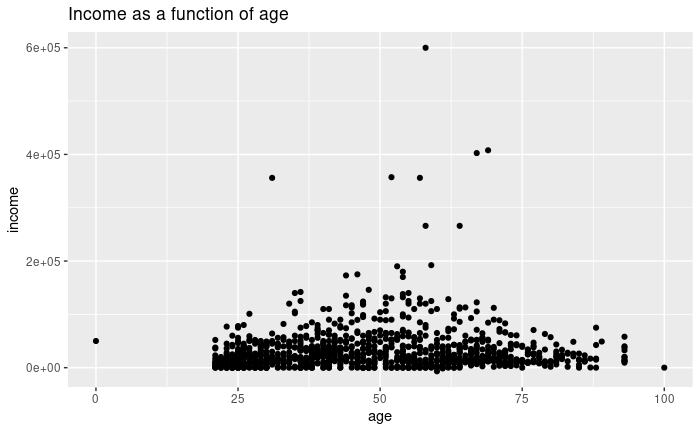

```r
#collect sample customer data
cust_sample=head(customer_data,1000)
ggplot(cust_sample, aes(x=age, y=income))+ geom_point()+ggtitle("Income as a function of age")
```

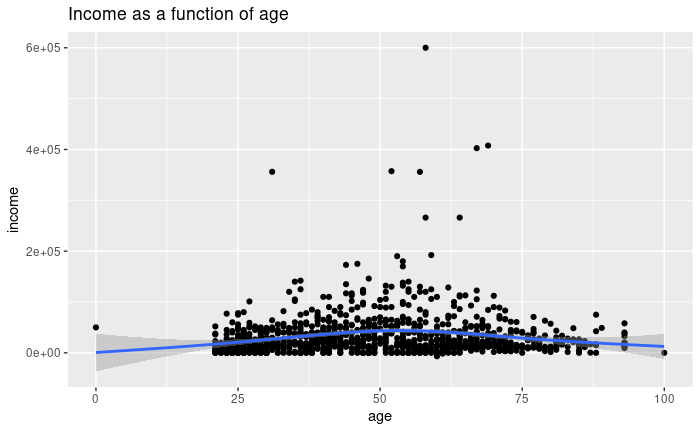

```r
ggplot(cust_sample, aes(x=age, y=income))+ geom_point()+ggtitle("Income as a function of age")+geom_smooth()
```

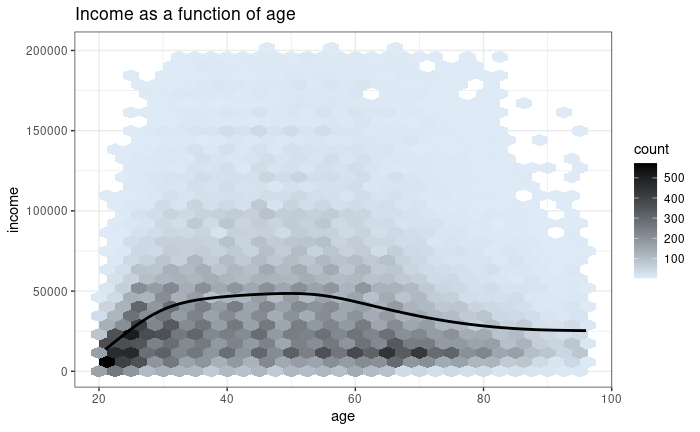

```r
library(WVPlots)
HexBinPlot(customer_data2, "age", "income", "Income as a function of age") +
geom_smooth(color="black", se=FALSE)
```

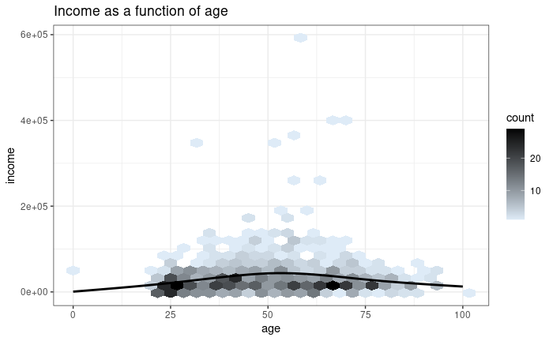

```r
#Adds the smoothing line in black; suppresses standard error ribbon (se=FALSE)
HexBinPlot(cust_sample, "age", "income", "Income as a function of age") +
geom_smooth(color="black", se=FALSE)
```

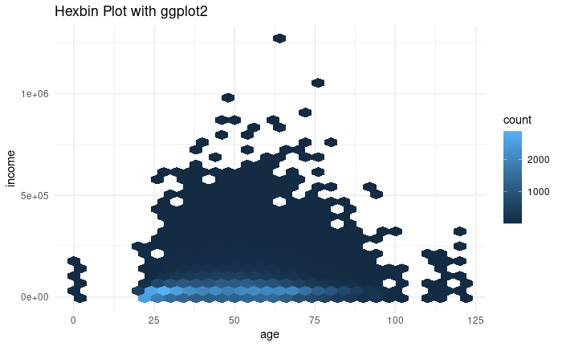

```r
ggplot(customer_data, aes(age, income)) +
  geom_hex() +
  labs(title = "Hexbin Plot with ggplot2") +
  theme_minimal()
```

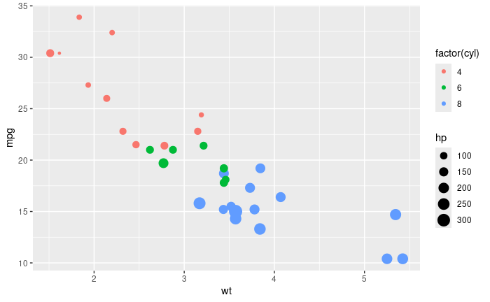

```r
library(ggplot2)

# Scatter plot with x, y, color, and size aesthetics
ggplot(mtcars, aes(x = wt, y = mpg, color = factor(cyl), size = hp)) +
  geom_point()
```

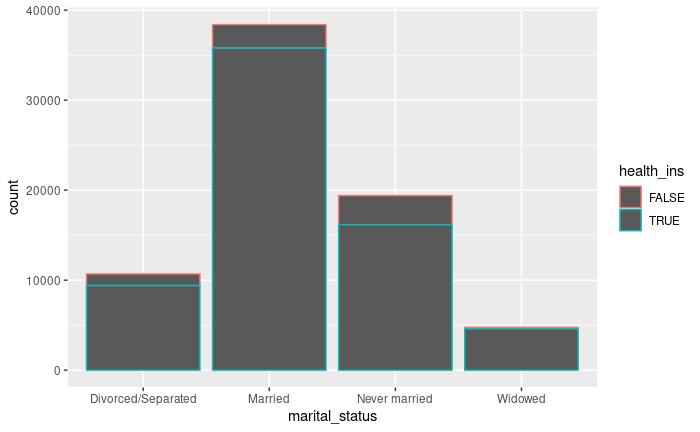

```r
#Stacked bar chart, the default
ggplot(customer_data, aes(x=marital_status, colour =health_ins)  ) +
geom_bar()
```

Side-by-side bar chart

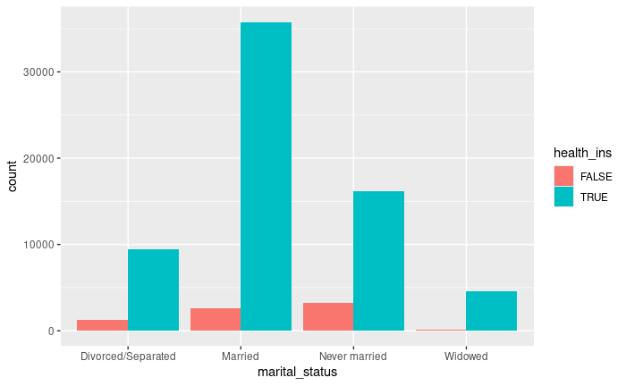

```r
ggplot(customer_data, aes(x=marital_status, fill =health_ins)) +
geom_bar(position = "dodge")
```

Uses the ShadowPlot command from the WVPlots package for the shadow plot

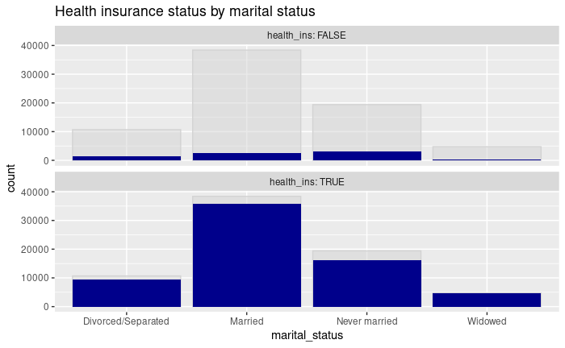

```r
ShadowPlot(customer_data, "marital_status", "health_ins", title = "Health insurance status by marital status")
```

Filled bar chart

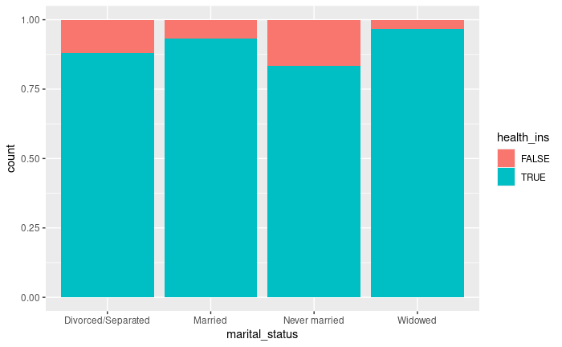

```r
ggplot(customer_data, aes(x=marital_status, fill=health_ins)) +
geom_bar(position = "fill")
```

```r
?mutate
```

library(dplyr)

data <- data %>% mutate(new_variable = case_when( condition1 ~ value1, condition2 ~ value2, condition3 ~ value3, TRUE ~ default_value ))

```r
library(dplyr)

df <- data.frame(
  score = c(85, 45, 70, 90, 50)
)

df <- df %>%
  mutate(grade = case_when(
    score >= 85 ~ "A",
    score >= 70 ~ "B",
    score >= 50 ~ "C",
    TRUE ~ "F"
  ))

print(df)
```

| score | grade |
| --- | --- |
| 85 | A |
| 45 | F |
| 70 | B |
| 90 | A |
| 50 | C |

```r
NA
```

```r
library(dplyr)
customer_data<-read.csv("custdata.csv")
#h1=head(customer_data)
h1=customer_data
print(h1)
```

| custid | gender | is_employed | income | marital_status | health_ins | housing_type | recent_move | num_vehicles | age | state_of_res | gas_usage |
| --- | --- | --- | --- | --- | --- | --- | --- | --- | --- | --- | --- |
| 000006646_03 | Male | TRUE | 22000 | Never married | TRUE | Homeowner free and clear | FALSE | 0 | 24 | Alabama | 210 |
| 000007827_01 | Female | NA | 23200 | Divorced/Separated | TRUE | Rented | TRUE | 0 | 82 | Alabama | 3 |
| 000008359_04 | Female | TRUE | 21000 | Never married | TRUE | Homeowner with mortgage/loan | FALSE | 2 | 31 | Alabama | 40 |
| 000008529_01 | Female | NA | 37770 | Widowed | TRUE | Homeowner free and clear | FALSE | 1 | 93 | Alabama | 120 |
| 000008744_02 | Male | TRUE | 39000 | Divorced/Separated | TRUE | Rented | FALSE | 2 | 67 | Alabama | 3 |
| 000011466_01 | Male | NA | 11100 | Married | TRUE | Homeowner free and clear | FALSE | 2 | 76 | Alabama | 200 |
| 000015018_01 | Female | TRUE | 25800 | Married | FALSE | Rented | FALSE | 2 | 26 | Alabama | 3 |
| 000017314_02 | Female | NA | 34600 | Married | TRUE | Homeowner free and clear | FALSE | 2 | 73 | Alabama | 50 |
| 000017383_04 | Female | TRUE | 25000 | Never married | TRUE | Homeowner free and clear | FALSE | 5 | 27 | Alabama | 3 |
| 000017554_02 | Male | TRUE | 31200 | Married | TRUE | Homeowner with mortgage/loan | FALSE | 3 | 54 | Alabama | 20 |

[output cut: 990 more lines]

```r
h1<-mutate(h1,age1=case_when(age==0 ~ as.numeric(NA),TRUE ~age))

c<-customer_data %>% mutate(
        gas_with_rent=case_when(gas_usage==1 ~TRUE,
                                TRUE ~FALSE))

h1<-mutate(h1,income=case_when(income<0 ~ NA, TRUE ~income))
```

```r
count_missing=function(df) {
  sapply(df,function(col) sum(is.na(col)) )
}

nacounts<-count_missing(customer_data)
print(nacounts)
```

```
        custid         gender    is_employed         income marital_status
             0              0          25774              0              0
    health_ins   housing_type    recent_move   num_vehicles            age
             0           1720           1721           1720              0
  state_of_res      gas_usage
             0           1720
```

```r
sum(is.na(customer_data))
```

```
[1] 32655
```

```r
sapply(1:5, function(x) x + 5)
```

```
[1]  6  7  8  9 10
```

```r
h=head(customer_data)
print(h)
```

|  | custid | gender | is_employed | income | marital_status | health_ins | housing_type | recent_move | num_vehicles | age | state_of_res | gas_usage |
| --- | --- | --- | --- | --- | --- | --- | --- | --- | --- | --- | --- | --- |
| 1 | 000006646_03 | Male | TRUE | 22000 | Never married | TRUE | Homeowner free and clear | FALSE | 0 | 24 | Alabama | 210 |
| 2 | 000007827_01 | Female | NA | 23200 | Divorced/Separated | TRUE | Rented | TRUE | 0 | 82 | Alabama | 3 |
| 3 | 000008359_04 | Female | TRUE | 21000 | Never married | TRUE | Homeowner with mortgage/loan | FALSE | 2 | 31 | Alabama | 40 |
| 4 | 000008529_01 | Female | NA | 37770 | Widowed | TRUE | Homeowner free and clear | FALSE | 1 | 93 | Alabama | 120 |
| 5 | 000008744_02 | Male | TRUE | 39000 | Divorced/Separated | TRUE | Rented | FALSE | 2 | 67 | Alabama | 3 |
| 6 | 000011466_01 | Male | NA | 11100 | Married | TRUE | Homeowner free and clear | FALSE | 2 | 76 | Alabama | 200 |

```r
count=1
sapply(h, function(col) {
  print(col)
  #return(NA)  # or return(0), return(TRUE), etc.
})
```

```
[1] "000006646_03" "000007827_01" "000008359_04" "000008529_01" "000008744_02"
[6] "000011466_01"
[1] "Male"   "Female" "Female" "Female" "Male"   "Male"
[1] TRUE   NA TRUE   NA TRUE   NA
[1] 22000 23200 21000 37770 39000 11100
[1] "Never married"      "Divorced/Separated" "Never married"
[4] "Widowed"            "Divorced/Separated" "Married"
[1] TRUE TRUE TRUE TRUE TRUE TRUE
[1] "Homeowner free and clear"     "Rented"
[3] "Homeowner with mortgage/loan" "Homeowner free and clear"
[5] "Rented"                       "Homeowner free and clear"
[1] FALSE  TRUE FALSE FALSE FALSE FALSE
[1] 0 0 2 1 2 2
[1] 24 82 31 93 67 76
[1] "Alabama" "Alabama" "Alabama" "Alabama" "Alabama" "Alabama"
```

[output cut: 22 more lines]

```r
print(count)
```

```
[1] 1
```

```r
count_missing = function(df) {
sapply(df, FUN=function(col) sum(is.na(col)) )
}
nacounts <- count_missing(customer_data)
hasNA = which(nacounts > 0)
#nacounts[hasNA]

hasNA=which(nacounts>0)
print(customer_data)
```

| custid | gender | is_employed | income | marital_status | health_ins | housing_type | recent_move | num_vehicles | age | state_of_res | gas_usage |
| --- | --- | --- | --- | --- | --- | --- | --- | --- | --- | --- | --- |
| 000006646_03 | Male | TRUE | 22000 | Never married | TRUE | Homeowner free and clear | FALSE | 0 | 24 | Alabama | 210 |
| 000007827_01 | Female | NA | 23200 | Divorced/Separated | TRUE | Rented | TRUE | 0 | 82 | Alabama | 3 |
| 000008359_04 | Female | TRUE | 21000 | Never married | TRUE | Homeowner with mortgage/loan | FALSE | 2 | 31 | Alabama | 40 |
| 000008529_01 | Female | NA | 37770 | Widowed | TRUE | Homeowner free and clear | FALSE | 1 | 93 | Alabama | 120 |
| 000008744_02 | Male | TRUE | 39000 | Divorced/Separated | TRUE | Rented | FALSE | 2 | 67 | Alabama | 3 |
| 000011466_01 | Male | NA | 11100 | Married | TRUE | Homeowner free and clear | FALSE | 2 | 76 | Alabama | 200 |
| 000015018_01 | Female | TRUE | 25800 | Married | FALSE | Rented | FALSE | 2 | 26 | Alabama | 3 |
| 000017314_02 | Female | NA | 34600 | Married | TRUE | Homeowner free and clear | FALSE | 2 | 73 | Alabama | 50 |
| 000017383_04 | Female | TRUE | 25000 | Never married | TRUE | Homeowner free and clear | FALSE | 5 | 27 | Alabama | 3 |
| 000017554_02 | Male | TRUE | 31200 | Married | TRUE | Homeowner with mortgage/loan | FALSE | 3 | 54 | Alabama | 20 |

[output cut: 990 more lines]

```r
print("------------------------------------")
```

```
[1] "------------------------------------"
```

```r
print(hasNA)
```

```
 is_employed housing_type  recent_move num_vehicles    gas_usage
           3            7            8            9           12
```

```r
print("------------------------------------")
```

```
[1] "------------------------------------"
```

```r
print(nacounts)
```

```
        custid         gender    is_employed         income marital_status
             0              0          25774              0              0
    health_ins   housing_type    recent_move   num_vehicles            age
             0           1720           1721           1720              0
  state_of_res      gas_usage
             0           1720
```

```r
library(vtreat)
varlist<-setdiff(colnames(customer_data),c('custid','health_ins'))
treatment_plan<-design_missingness_treatment(customer_data,varlist=varlist)
training_prepared<-prepare(treatment_plan,customer_data)
```

```r
a=colnames(customer_data)
b=colnames(training_prepared)
cat(a,"\n")
```

```
custid gender is_employed income marital_status health_ins housing_type recent_move num_vehicles age state_of_res gas_usage
```

```r
print('---')
```

```
[1] "---"
```

```r
cat(b)
```

```
custid health_ins gender is_employed is_employed_isBAD income marital_status housing_type recent_move recent_move_isBAD num_vehicles num_vehicles_isBAD age state_of_res gas_usage gas_usage_isBAD
```

```r
is.na(customer_data)
```

```
         custid gender is_employed income marital_status health_ins
    [1,]  FALSE  FALSE       FALSE  FALSE          FALSE      FALSE
    [2,]  FALSE  FALSE        TRUE  FALSE          FALSE      FALSE
    [3,]  FALSE  FALSE       FALSE  FALSE          FALSE      FALSE
    [4,]  FALSE  FALSE        TRUE  FALSE          FALSE      FALSE
    [5,]  FALSE  FALSE       FALSE  FALSE          FALSE      FALSE
    [6,]  FALSE  FALSE        TRUE  FALSE          FALSE      FALSE
    [7,]  FALSE  FALSE       FALSE  FALSE          FALSE      FALSE
    [8,]  FALSE  FALSE        TRUE  FALSE          FALSE      FALSE
    [9,]  FALSE  FALSE       FALSE  FALSE          FALSE      FALSE
   [10,]  FALSE  FALSE       FALSE  FALSE          FALSE      FALSE
   [11,]  FALSE  FALSE        TRUE  FALSE          FALSE      FALSE
   [12,]  FALSE  FALSE       FALSE  FALSE          FALSE      FALSE
   [13,]  FALSE  FALSE        TRUE  FALSE          FALSE      FALSE
   [14,]  FALSE  FALSE        TRUE  FALSE          FALSE      FALSE
```

[output cut: 154 more lines]

```r
ncol(customer_data)
```

```
[1] 12
```

# Remove rows where column ‘col_name’ has NA

cleaned_data <- subset(data, !is.na(data$col_name))

```r
# Remove rows where column 'col_name' has NA
cleaned_data <- subset(customer_data, !is.na(customer_data$is_employed))
```